# Tidyverse and Data Visualization

R Programming

Data wrangling

Data visualization

A hands‑on Tidyverse and data‑visualization exercise in which participants practice converting data frames to tibbles, manipulating and reordering data with dplyr and creating scatterplots with `ggplot2`. Participants practice factoring levels to control plot ordering, how to customize visual elements and how to save results to files.

Authors

Meeta Mistry

Mary Piper

Radhika Khetani

Will Gammerdinger

Published

May 30, 2025

Keywords

R, tidyverse, dplyr, ggplot2

## **Exercises**

1. Change the `animals` data frame to a tibble called `animals_tb`. Save the row names to a column called `animal_names` before turning it into a tibble.

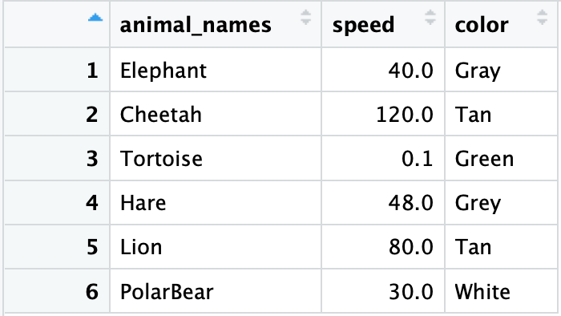

2. Use ggplot2 to plot the animal names (x-axis) versus the speed of the animal (y-axis) in `animals_tb` using a scatterplot. Customize the plot to display as shown below.

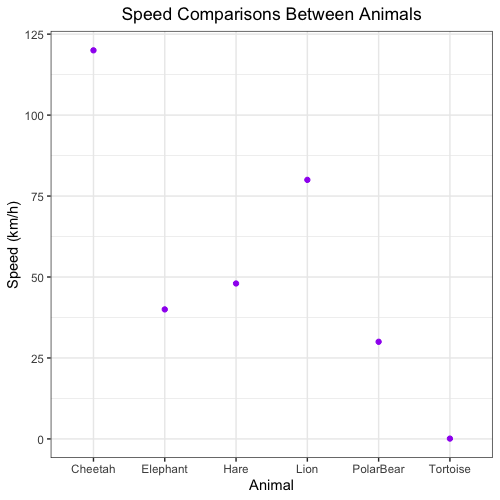

3. We decide that our plot would look better with the animal names ordered from slowest to fastest. Using the `animals_tb` tibble, reorder the animals on the x-axis to start with the slowest animal on the left-hand side of the plot to the fastest animal on the right-hand side of the plot by completing the following steps:

   **a.** Use the `arrange()` function to order the rows by speed from slowest to fastest. Then use the `pull()` function to extract the `animal_names` column as a vector of character values. Save the new variable as `names_ordered_by_speed`.

   **b.** Turn the `animal_names` column of `animals_tb` into a factor and specify the levels as `names_ordered_by_speed` from slowest to fastest (output in part a). Note: this step is crucial, because ggplot2 uses `factor` as plotting order, instead of the order we observe in data frame.

   **c.** Re-plot the scatterplot with the animal names in order from slowest to fastest.

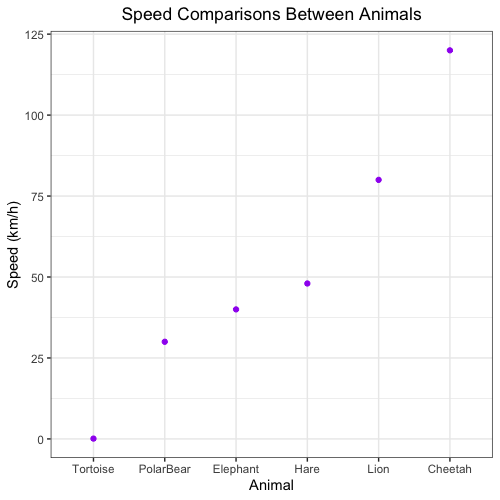

**Note**

If you are interested in exploring other ways to reorder a variable in ggplot2, refer to this [post](https://www.r-graph-gallery.com/267-reorder-a-variable-in-ggplot2.html).

4. Save the plot as a PDF called `animals_by_speed_scatterplot.pdf` to the `results` folder.
5. Use the functions from the `dplyr` package to perform the following tasks:

**a.** Extract the rows of `animals_tb` tibble with color of gray or tan, order the rows based from slowest to fastest speed, and save to a variable called `animals_gray_tan`.

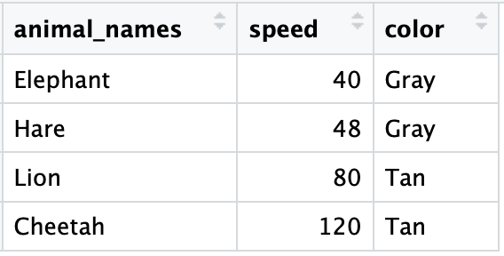

**b.** Save `animals_gray_tan` as a comma-separated value file called `animals_tb_ordered.csv` to the `results` folder.